# AED Conceitos - Aula 1

Fabrício Venturim

2023-04-25

```r
if(!require(utf8)) install.packages("utf8")
library(utf8)
Sys.setlocale("LC_ALL", "pt_br.utf-8")
```

```
## [1] ""
```

# 1 Análise Exploratória de Dados

Aprenderemos como usar a visualização e a transformação para explorar seus dados de maneira sistemática.

A Análise Exploratória de Dados (AED) é uma das etapas fundamentais no processo de análise de dados. Ela tem como objetivo compreender os dados disponíveis, identificar padrões, tendências, valores extremos e outras características importantes dos dados. A AED pode ser realizada por meio de **visualizações**, **estatísticas descritivas** e outras técnicas exploratórias.

O R é uma linguagem de programação muito utilizada em análise de dados e possui diversas bibliotecas e ferramentas que facilitam a realização da AED. Uma das bibliotecas mais populares é o tidyverse, que contém uma série de pacotes que permitem a manipulação, visualização e modelagem de dados.

Neste documento, iremos explorar algumas técnicas de AED utilizando o R e o tidyverse. Iremos aprender como carregar dados em R, manipulá-los e visualizá-los para obter insights valiosos sobre o conjunto de dados. Além disso, iremos explorar técnicas de limpeza e pré-processamento de dados para garantir que os dados estejam prontos para serem utilizados em análises mais avançadas.

> “Far better an approximate answer to the right question, which is often vague, than an exact answer to the wrong question, which can always be made precise.” — **John Tukey**

Seu objetivo durante a EDA é desenvolver uma compreensão de seus dados. A maneira mais fácil de fazer isso é usar perguntas como ferramentas para orientar sua investigação. Quando você faz uma pergunta, ela concentra sua atenção em uma parte específica do seu conjunto de dados e ajuda a decidir quais gráficos, modelos ou transformações fazer.

**Uma postura crucial é compreender os conceitos fundamentais da AED, uma vez que, tendo uma compreensão clara da teoria e do processo de análise, a escolha da linguagem de programação torna-se menos relevante. Isso significa que os conceitos abordados são aplicáveis não apenas ao R, mas a outras linguagens também.**

## 1.1 Componentes da AED

Existem componentes principais na exploração de dados:

1. Entender suas variáveis
2. Limpar seu conjunto de dados (Próxima aula)
3. Analisar relações entre variáveis

## 1.2 Pré-requisitos

Vamos importar a biblioteca do `tidyverse`.

```r
install.packages("tidyverse")
if(!require(tidyverse)){
  install.packages("tidyverse")
}
if(!require(tidyverse)) install.packages("tidyverse")
if(!require(ggthemes)) install.packages("ggthemes")
library(tidyverse)
library(ggthemes)
```

## 1.3 Dados da Tarefa

```r
if(!require(gapminder)) install.packages("gapminder")
library(gapminder)
```

```r
gapminder
```

```
## # A tibble: 1,704 × 6
##    country     continent  year lifeExp      pop gdpPercap
##    <fct>       <fct>     <int>   <dbl>    <int>     <dbl>
##  1 Afghanistan Asia       1952    28.8  8425333      779.
##  2 Afghanistan Asia       1957    30.3  9240934      821.
##  3 Afghanistan Asia       1962    32.0 10267083      853.
##  4 Afghanistan Asia       1967    34.0 11537966      836.
##  5 Afghanistan Asia       1972    36.1 13079460      740.
##  6 Afghanistan Asia       1977    38.4 14880372      786.
##  7 Afghanistan Asia       1982    39.9 12881816      978.
##  8 Afghanistan Asia       1987    40.8 13867957      852.
##  9 Afghanistan Asia       1992    41.7 16317921      649.
## 10 Afghanistan Asia       1997    41.8 22227415      635.
## # ℹ 1,694 more rows
```

## 1.4 Gráficos

- **1º Gráfico:** A seguir esta o gráfico do exemplo do livro:

```r
graf <- ggplot(data = gapminder, mapping = aes(x= gdpPercap, y = lifeExp)) +
  geom_point() +
  geom_smooth(method = "lm") +
  scale_x_log10(labels= scales::dollar)
```

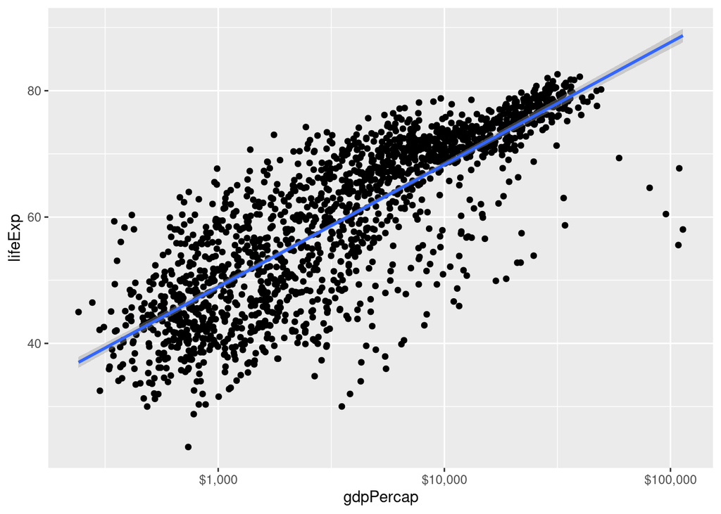

```r
graf
```

```r
graf <- ggplot(data = gapminder, mapping = aes(x= gdpPercap, y = lifeExp)) +
  geom_point(color = "brown", alpha = 0.5) +
  geom_smooth(method = "lm", color = "black") +
  scale_x_log10(labels= scales::dollar) +
  theme_igray() +
  labs(x = "Pib per capita", y = "Expectativa de vida em anos",
       title = "Crescimento Econômico e Expectativa de Vida",
       caption = "Fonte: Gapminder.")
```

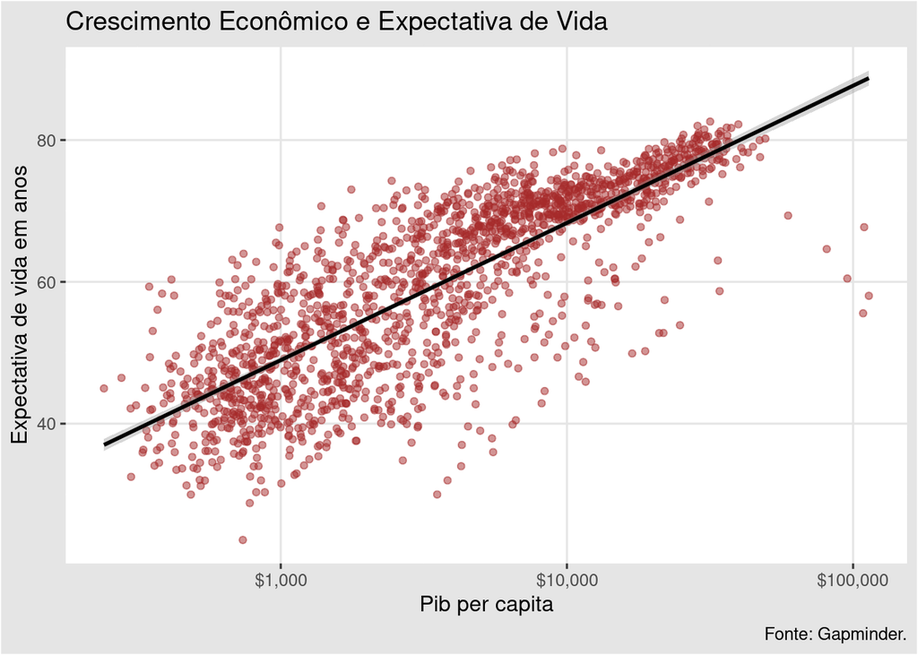

```r
graf
```

## 1.5 Leitura de dataframe por csv

O livro “Estatística Básica” de W. O. Bussab e P. A. Morettin traz no segundo capítulo um conjunto de dados hipotético de atributos de 36 funcionários da companhia “Milsa”. Os dados estão reproduzidos na tabela abaixo. Consulte o livro para mais detalhes sobre este dados.

Ler o csv `Tabela1.csv`:

```r
milsa <- read.csv("data/Tabela1.csv")
```

```r
milsa
```

```
##     N Estado.Civil  Grau.de.Instrução N.de.Filhos Salario..x.Sal.Min. Anos
## 1   1     solteiro ensino fundamental           2                4.00   26
## 2   2       casado ensino fundamental           1                4.56   32
## 3   3       casado ensino fundamental           2                5.25   36
## 4   4     solteiro       ensino médio           1                5.73   20
## 5   5     solteiro ensino fundamental           0                6.26   40
## 6   6       casado ensino fundamental           0                6.66   28
## 7   7     solteiro ensino fundamental           1                6.86   41
## 8   8     solteiro ensino fundamental           2                7.39   43
## 9   9       casado       ensino médio           1                7.59   34
## 10 10     solteiro       ensino médio           4                7.44   23
## 11 11       casado       ensino médio           2                8.12   33
## 12 12     solteiro ensino fundamental           0                8.46   27
## 13 13     solteiro       ensino médio           0                8.74   37
## 14 14       casado ensino fundamental           3                8.95   44
```

[output cut: 59 more lines]

## 1.6 Estrutura do Dataframe

### 1.6.1 Adicionar Colunas no Dataframe

Podemos definir uma nova variável (coluna), por exemplo, chamada `Idade`, a partir das variáveis `Anos` e `Meses`:

```r
milsa$Idade <- milsa$Anos + milsa$Meses/12
```

```r
milsa
```

```
##     N Estado.Civil  Grau.de.Instrução N.de.Filhos Salario..x.Sal.Min. Anos
## 1   1     solteiro ensino fundamental           2                4.00   26
## 2   2       casado ensino fundamental           1                4.56   32
## 3   3       casado ensino fundamental           2                5.25   36
## 4   4     solteiro       ensino médio           1                5.73   20
## 5   5     solteiro ensino fundamental           0                6.26   40
## 6   6       casado ensino fundamental           0                6.66   28
## 7   7     solteiro ensino fundamental           1                6.86   41
## 8   8     solteiro ensino fundamental           2                7.39   43
## 9   9       casado       ensino médio           1                7.59   34
## 10 10     solteiro       ensino médio           4                7.44   23
## 11 11       casado       ensino médio           2                8.12   33
## 12 12     solteiro ensino fundamental           0                8.46   27
## 13 13     solteiro       ensino médio           0                8.74   37
## 14 14       casado ensino fundamental           3                8.95   44
```

[output cut: 59 more lines]

- Adicionar coluna: `table$colunaNova`
- Atualizar coluna: `table$colunaAtualizar`

## 1.7 Excluir Coluna

Também podemos excluir coluna do nosso dataframe:

```r
milsa <- subset(milsa, select = -X)
```

Se quiser apagar mais de uma coluna, utilize: `milsa <- subset(milsa, select = -c(Meses, Ano))`.

## 1.8 Mudar Nome de colunas

Para ver os nomes das colunas do nosso dataframe, podemos utilizar a função `names()`.

```r
names(milsa)
```

```
## [1] "N"                     "Estado.Civil"          "Grau.de.Instrução"
## [4] "N.de.Filhos"           "Salario..x.Sal.Min."   "Anos"
## [7] "Meses"                 "Região.de.Procedência" "Idade"
```

Alguns nomes estão escritos de forma estranha e pode facilitar futuras análises alterar o nome delas. Podemos alterar o nome das colunas usando um filtro no `names`:

```r
names(milsa)[names(milsa) == "Salario..x.Sal.Min."] <- "Salario"
names(milsa)[names(milsa) == "N.de.Filhos"] <- "Filhos"
names(milsa)[names(milsa) == "Grau.de.Instrução"] <- "Grau_Instrucao"
names(milsa)[names(milsa) == "Região.de.Procedência"] <- "Regiao_Procedencia"
names(milsa)[names(milsa) == "Estado.Civil"] <- "Estado_Civil"
```

```r
milsa
```

```
##     N Estado_Civil     Grau_Instrucao Filhos Salario Anos Meses
## 1   1     solteiro ensino fundamental      2    4.00   26     3
## 2   2       casado ensino fundamental      1    4.56   32    10
## 3   3       casado ensino fundamental      2    5.25   36     5
## 4   4     solteiro       ensino médio      1    5.73   20    10
## 5   5     solteiro ensino fundamental      0    6.26   40     7
## 6   6       casado ensino fundamental      0    6.66   28     0
## 7   7     solteiro ensino fundamental      1    6.86   41     0
## 8   8     solteiro ensino fundamental      2    7.39   43     4
## 9   9       casado       ensino médio      1    7.59   34    10
## 10 10     solteiro       ensino médio      4    7.44   23     6
## 11 11       casado       ensino médio      2    8.12   33     6
## 12 12     solteiro ensino fundamental      0    8.46   27    11
## 13 13     solteiro       ensino médio      0    8.74   37     5
## 14 14       casado ensino fundamental      3    8.95   44     2
```

[output cut: 59 more lines]

## 1.9 Medidas Estatísticas

Uma boa forma de iniciar uma análise exploratória adequada é verificar os tipos de variáveis disponíveis. Variáveis podem ser classificadas da seguinte forma:

- Qualitativas
  - Nominais
  - Ordinais
- Quantitativas
  - Discretas
  - Contínuas

e podem ser resumidas por tabelas, gráficos e/ou medidas.

### 1.9.1 Variável Quantitativa Discreta

Vamos agora usar a variável `Filhos` (número de filhos) para ilustrar algumas análises que podem ser feitas com uma quantitativa discreta.

```r
filhos_tb <- table(milsa$Filhos)
filhos_tb
```

```
##
##  0  1  2  3  4  5
##  8 10 12  4  1  1
```

```r
filhos_tbr <- prop.table(filhos_tb)
filhos_tbr
```

```
##
##          0          1          2          3          4          5
## 0.22222222 0.27777778 0.33333333 0.11111111 0.02777778 0.02777778
```

#### 1.9.1.1 Frequência Acumulada

```r
freq_rel_acum <- cumsum(filhos_tbr)
freq_rel_acum
```

```
##         0         1         2         3         4         5
## 0.2222222 0.5000000 0.8333333 0.9444444 0.9722222 1.0000000
```

#### 1.9.1.2 Gráfico de Frequência

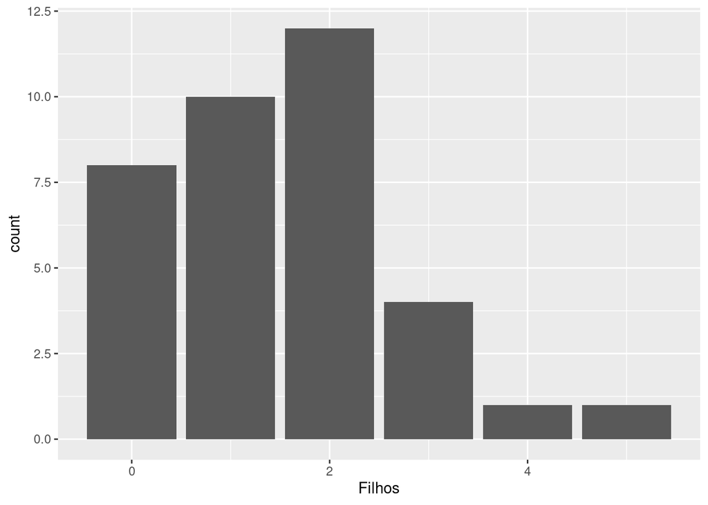

```r
ggplot(milsa, aes(x = Filhos)) + geom_bar()
```

#### 1.9.1.3 Medidas (moda, mediana e média)

```r
names(filhos_tb)[which.max(filhos_tb)]
```

```
## [1] "2"
```

```r
median(milsa$Filhos)
```

```
## [1] 1.5
```

```r
mean(milsa$Filhos)
```

```
## [1] 1.527778
```

#### 1.9.1.4 Forma Prática

Podemos usar a função genérica `summary()` para resumir os dados de uma só vez:

```r
summary(milsa$Filhos)
```

```
##    Min. 1st Qu.  Median    Mean 3rd Qu.    Max.
##   0.000   1.000   1.500   1.528   2.000   5.000
```